# Risk Factor Analysis

## Outcome Variable

**Outcome Variable:** y_rate_wtkg

## Predictor Variables

**Intervention Variable:** fhtcm

**Adjustment Set:**

unadjusted

## Stratifying Variables

The analysis was stratified on these variable(s):

- agecat
- studyid
- country

## Data Summary

| agecat | studyid | country | fhtcm | n_cell | n |
| --- | --- | --- | --- | --- | --- |
| 0-3 months | COHORTS | GUATEMALA | >=167 cm | 37 | 243 |
| 0-3 months | COHORTS | GUATEMALA | <162 cm | 141 | 243 |
| 0-3 months | COHORTS | GUATEMALA | [162-167) cm | 65 | 243 |
| 0-3 months | Keneba | GAMBIA | >=167 cm | 768 | 1181 |
| 0-3 months | Keneba | GAMBIA | <162 cm | 82 | 1181 |
| 0-3 months | Keneba | GAMBIA | [162-167) cm | 331 | 1181 |
| 0-3 months | PROBIT | BELARUS | >=167 cm | 10778 | 11505 |
| 0-3 months | PROBIT | BELARUS | <162 cm | 151 | 11505 |
| 0-3 months | PROBIT | BELARUS | [162-167) cm | 576 | 11505 |
| 0-3 months | SAS-CompFeed | INDIA | >=167 cm | 347 | 768 |
| 0-3 months | SAS-CompFeed | INDIA | <162 cm | 197 | 768 |
| 0-3 months | SAS-CompFeed | INDIA | [162-167) cm | 224 | 768 |
| 3-6 months | COHORTS | GUATEMALA | >=167 cm | 37 | 263 |
| 3-6 months | COHORTS | GUATEMALA | <162 cm | 150 | 263 |
| 3-6 months | COHORTS | GUATEMALA | [162-167) cm | 76 | 263 |
| 3-6 months | Keneba | GAMBIA | >=167 cm | 673 | 1039 |
| 3-6 months | Keneba | GAMBIA | <162 cm | 75 | 1039 |
| 3-6 months | Keneba | GAMBIA | [162-167) cm | 291 | 1039 |
| 3-6 months | PROBIT | BELARUS | >=167 cm | 9478 | 10109 |
| 3-6 months | PROBIT | BELARUS | <162 cm | 129 | 10109 |
| 3-6 months | PROBIT | BELARUS | [162-167) cm | 502 | 10109 |
| 3-6 months | SAS-CompFeed | INDIA | >=167 cm | 309 | 681 |
| 3-6 months | SAS-CompFeed | INDIA | <162 cm | 173 | 681 |
| 3-6 months | SAS-CompFeed | INDIA | [162-167) cm | 199 | 681 |
| 6-9 months | COHORTS | GUATEMALA | >=167 cm | 40 | 309 |
| 6-9 months | COHORTS | GUATEMALA | <162 cm | 187 | 309 |
| 6-9 months | COHORTS | GUATEMALA | [162-167) cm | 82 | 309 |
| 6-9 months | Keneba | GAMBIA | >=167 cm | 442 | 663 |
| 6-9 months | Keneba | GAMBIA | <162 cm | 53 | 663 |
| 6-9 months | Keneba | GAMBIA | [162-167) cm | 168 | 663 |

[output cut: 72 more lines]

The following strata were considered:

- agecat: 0-3 months, studyid: COHORTS, country: GUATEMALA
- agecat: 0-3 months, studyid: Keneba, country: GAMBIA
- agecat: 0-3 months, studyid: PROBIT, country: BELARUS
- agecat: 0-3 months, studyid: SAS-CompFeed, country: INDIA
- agecat: 12-15 months, studyid: COHORTS, country: GUATEMALA
- agecat: 12-15 months, studyid: Keneba, country: GAMBIA
- agecat: 12-15 months, studyid: PROBIT, country: BELARUS
- agecat: 12-15 months, studyid: SAS-CompFeed, country: INDIA
- agecat: 12-15 months, studyid: SAS-FoodSuppl, country: INDIA
- agecat: 15-18 months, studyid: COHORTS, country: GUATEMALA
- agecat: 15-18 months, studyid: Keneba, country: GAMBIA
- agecat: 15-18 months, studyid: PROBIT, country: BELARUS
- agecat: 15-18 months, studyid: SAS-CompFeed, country: INDIA
- agecat: 15-18 months, studyid: SAS-FoodSuppl, country: INDIA
- agecat: 18-21 months, studyid: COHORTS, country: GUATEMALA
- agecat: 18-21 months, studyid: Keneba, country: GAMBIA
- agecat: 18-21 months, studyid: PROBIT, country: BELARUS
- agecat: 21-24 months, studyid: COHORTS, country: GUATEMALA
- agecat: 21-24 months, studyid: Keneba, country: GAMBIA
- agecat: 21-24 months, studyid: PROBIT, country: BELARUS
- agecat: 3-6 months, studyid: COHORTS, country: GUATEMALA
- agecat: 3-6 months, studyid: Keneba, country: GAMBIA
- agecat: 3-6 months, studyid: PROBIT, country: BELARUS
- agecat: 3-6 months, studyid: SAS-CompFeed, country: INDIA
- agecat: 6-9 months, studyid: COHORTS, country: GUATEMALA
- agecat: 6-9 months, studyid: Keneba, country: GAMBIA
- agecat: 6-9 months, studyid: PROBIT, country: BELARUS
- agecat: 6-9 months, studyid: SAS-CompFeed, country: INDIA
- agecat: 6-9 months, studyid: SAS-FoodSuppl, country: INDIA
- agecat: 9-12 months, studyid: COHORTS, country: GUATEMALA
- agecat: 9-12 months, studyid: Keneba, country: GAMBIA
- agecat: 9-12 months, studyid: PROBIT, country: BELARUS
- agecat: 9-12 months, studyid: SAS-CompFeed, country: INDIA
- agecat: 9-12 months, studyid: SAS-FoodSuppl, country: INDIA

### Dropped Strata

Some strata were dropped due to rare outcomes:

- agecat: 15-18 months, studyid: PROBIT, country: BELARUS
- agecat: 18-21 months, studyid: PROBIT, country: BELARUS
- agecat: 21-24 months, studyid: PROBIT, country: BELARUS

## Methods Detail

We’re interested in the causal parameters $E[Y_a]$ for all values of $a \in \mathcal{A}$. These parameters represent the mean outcome if, possibly contrary to fact, we intervened to set all units to have $A=a$. Under the randomization and positivity assumptions, these are identified by the statistical parameters $\psi_a=E_W[E_{Y|A,W}(Y|A=a,W)]$. In addition, we’re interested in the mean of $Y$, $E[Y]$ under no intervention (the observed mean). We will estimate these parameters by using SuperLearner to fit the relevant likelihood factors – $E_{Y|A,W}(Y|A=a,W)$ and $p(A=a|W)$, and then updating our likelihood fit using a joint TMLE.

For unadjusted analyses ($W=\{\}$), initial likelihoods were estimated using Lrnr_glm to estimate the simple $E(Y|A)$ and Lrnr_mean to estimate $p(A)$. For adjusted analyses, a small library containing Lrnr_glmnet, Lrnr_xgboost, and Lrnr_mean was used.

Having estimated these parameters, we will then use the delta method to estimate relative risks and attributable risks relative to a prespecified baseline level of $A$.

# Results Detail

## Results Plots

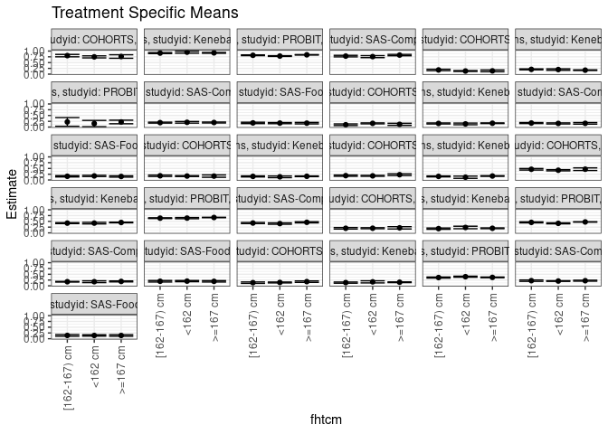

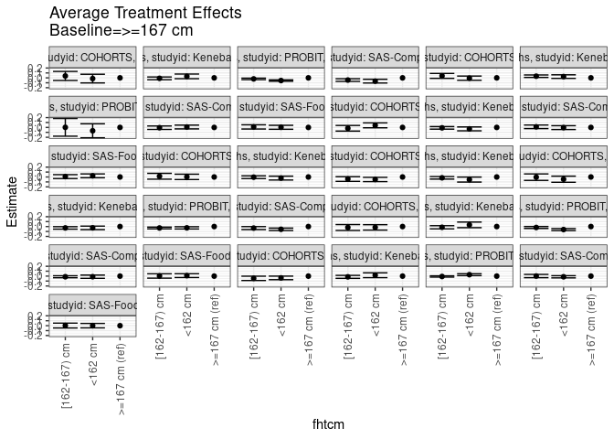

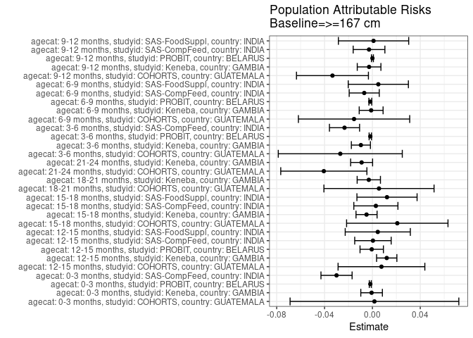

## Results Table

### Parameter: TSM

| agecat | studyid | country | intervention_level | baseline_level | estimate | ci_lower | ci_upper |
| --- | --- | --- | --- | --- | --- | --- | --- |
| 0-3 months | COHORTS | GUATEMALA | >=167 cm | NA | 0.7637871 | 0.6881753 | 0.8393989 |
| 0-3 months | COHORTS | GUATEMALA | <162 cm | NA | 0.7489013 | 0.7044401 | 0.7933625 |
| 0-3 months | COHORTS | GUATEMALA | [162-167) cm | NA | 0.8024712 | 0.7509540 | 0.8539884 |
| 0-3 months | Keneba | GAMBIA | >=167 cm | NA | 0.9218303 | 0.9064932 | 0.9371673 |
| 0-3 months | Keneba | GAMBIA | <162 cm | NA | 0.9523053 | 0.9078085 | 0.9968021 |
| 0-3 months | Keneba | GAMBIA | [162-167) cm | NA | 0.9118378 | 0.8884908 | 0.9351848 |
| 0-3 months | PROBIT | BELARUS | >=167 cm | NA | 0.8374233 | 0.8269572 | 0.8478893 |
| 0-3 months | PROBIT | BELARUS | <162 cm | NA | 0.7831043 | 0.7675162 | 0.7986923 |
| 0-3 months | PROBIT | BELARUS | [162-167) cm | NA | 0.8165455 | 0.7995884 | 0.8335027 |
| 0-3 months | SAS-CompFeed | INDIA | >=167 cm | NA | 0.8260324 | 0.7967179 | 0.8553470 |
| 0-3 months | SAS-CompFeed | INDIA | <162 cm | NA | 0.7594388 | 0.7156490 | 0.8032285 |
| 0-3 months | SAS-CompFeed | INDIA | [162-167) cm | NA | 0.7817877 | 0.7488102 | 0.8147653 |
| 3-6 months | COHORTS | GUATEMALA | >=167 cm | NA | 0.4674021 | 0.4107958 | 0.5240084 |
| 3-6 months | COHORTS | GUATEMALA | <162 cm | NA | 0.4221089 | 0.3961974 | 0.4480203 |
| 3-6 months | COHORTS | GUATEMALA | [162-167) cm | NA | 0.4638764 | 0.4302781 | 0.4974747 |
| 3-6 months | Keneba | GAMBIA | >=167 cm | NA | 0.4510309 | 0.4377209 | 0.4643409 |
| 3-6 months | Keneba | GAMBIA | <162 cm | NA | 0.4240612 | 0.3911826 | 0.4569399 |
| 3-6 months | Keneba | GAMBIA | [162-167) cm | NA | 0.4235976 | 0.4024279 | 0.4447673 |
| 3-6 months | PROBIT | BELARUS | >=167 cm | NA | 0.6671991 | 0.6592626 | 0.6751355 |
| 3-6 months | PROBIT | BELARUS | <162 cm | NA | 0.6409965 | 0.6151714 | 0.6668216 |
| 3-6 months | PROBIT | BELARUS | [162-167) cm | NA | 0.6385414 | 0.6215364 | 0.6555465 |
| 3-6 months | SAS-CompFeed | INDIA | >=167 cm | NA | 0.4589931 | 0.4334804 | 0.4845058 |
| 3-6 months | SAS-CompFeed | INDIA | <162 cm | NA | 0.4031514 | 0.3733537 | 0.4329490 |
| 3-6 months | SAS-CompFeed | INDIA | [162-167) cm | NA | 0.4277390 | 0.4028002 | 0.4526778 |
| 6-9 months | COHORTS | GUATEMALA | >=167 cm | NA | 0.2197857 | 0.1694418 | 0.2701297 |
| 6-9 months | COHORTS | GUATEMALA | <162 cm | NA | 0.2028251 | 0.1813126 | 0.2243375 |
| 6-9 months | COHORTS | GUATEMALA | [162-167) cm | NA | 0.2006475 | 0.1685949 | 0.2327001 |
| 6-9 months | Keneba | GAMBIA | >=167 cm | NA | 0.2007183 | 0.1834928 | 0.2179438 |
| 6-9 months | Keneba | GAMBIA | <162 cm | NA | 0.2348273 | 0.1807017 | 0.2889530 |
| 6-9 months | Keneba | GAMBIA | [162-167) cm | NA | 0.1858075 | 0.1587517 | 0.2128633 |

[output cut: 63 more lines]

### Parameter: E(Y)

| agecat | studyid | country | intervention_level | baseline_level | estimate | ci_lower | ci_upper |
| --- | --- | --- | --- | --- | --- | --- | --- |
| 0-3 months | COHORTS | GUATEMALA | NA | NA | 0.7654973 | 0.7339322 | 0.7970623 |
| 0-3 months | Keneba | GAMBIA | NA | NA | 0.9211456 | 0.9088113 | 0.9334799 |
| 0-3 months | PROBIT | BELARUS | NA | NA | 0.8356651 | 0.8251745 | 0.8461557 |
| 0-3 months | SAS-CompFeed | INDIA | NA | NA | 0.7960458 | 0.7686355 | 0.8234560 |
| 3-6 months | COHORTS | GUATEMALA | NA | NA | 0.4405506 | 0.4209873 | 0.4601139 |
| 3-6 months | Keneba | GAMBIA | NA | NA | 0.4414007 | 0.4306421 | 0.4521592 |
| 3-6 months | PROBIT | BELARUS | NA | NA | 0.6654416 | 0.6574980 | 0.6733852 |
| 3-6 months | SAS-CompFeed | INDIA | NA | NA | 0.4356742 | 0.4152410 | 0.4561073 |
| 6-9 months | COHORTS | GUATEMALA | NA | NA | 0.2044428 | 0.1875679 | 0.2213176 |
| 6-9 months | Keneba | GAMBIA | NA | NA | 0.1996667 | 0.1855792 | 0.2137542 |
| 6-9 months | PROBIT | BELARUS | NA | NA | 0.4728240 | 0.4638757 | 0.4817724 |
| 6-9 months | SAS-CompFeed | INDIA | NA | NA | 0.1837219 | 0.1641903 | 0.2032534 |
| 6-9 months | SAS-FoodSuppl | INDIA | NA | NA | 0.1989315 | 0.1824576 | 0.2154054 |
| 9-12 months | COHORTS | GUATEMALA | NA | NA | 0.1482194 | 0.1336860 | 0.1627527 |
| 9-12 months | Keneba | GAMBIA | NA | NA | 0.1517153 | 0.1384995 | 0.1649312 |
| 9-12 months | PROBIT | BELARUS | NA | NA | 0.3657561 | 0.3510684 | 0.3804439 |
| 9-12 months | SAS-CompFeed | INDIA | NA | NA | 0.2183762 | 0.2032601 | 0.2334924 |
| 9-12 months | SAS-FoodSuppl | INDIA | NA | NA | 0.1420248 | 0.1229762 | 0.1610734 |
| 12-15 months | COHORTS | GUATEMALA | NA | NA | 0.1495595 | 0.1344884 | 0.1646306 |
| 12-15 months | Keneba | GAMBIA | NA | NA | 0.1849266 | 0.1739388 | 0.1959143 |
| 12-15 months | PROBIT | BELARUS | NA | NA | 0.2199602 | 0.1433467 | 0.2965737 |
| 12-15 months | SAS-CompFeed | INDIA | NA | NA | 0.1982163 | 0.1855655 | 0.2108670 |
| 12-15 months | SAS-FoodSuppl | INDIA | NA | NA | 0.1741570 | 0.1580782 | 0.1902359 |
| 15-18 months | COHORTS | GUATEMALA | NA | NA | 0.1392318 | 0.1223264 | 0.1561372 |
| 15-18 months | Keneba | GAMBIA | NA | NA | 0.1612322 | 0.1498772 | 0.1725872 |
| 15-18 months | SAS-CompFeed | INDIA | NA | NA | 0.1646882 | 0.1450730 | 0.1843033 |
| 15-18 months | SAS-FoodSuppl | INDIA | NA | NA | 0.1645149 | 0.1487075 | 0.1803222 |
| 18-21 months | COHORTS | GUATEMALA | NA | NA | 0.1732169 | 0.1574345 | 0.1889994 |
| 18-21 months | Keneba | GAMBIA | NA | NA | 0.1562372 | 0.1442891 | 0.1681853 |
| 21-24 months | COHORTS | GUATEMALA | NA | NA | 0.1888602 | 0.1739625 | 0.2037579 |
| 21-24 months | Keneba | GAMBIA | NA | NA | 0.1630013 | 0.1513318 | 0.1746708 |

### Parameter: ATE

| agecat | studyid | country | intervention_level | baseline_level | estimate | ci_lower | ci_upper |
| --- | --- | --- | --- | --- | --- | --- | --- |
| 0-3 months | COHORTS | GUATEMALA | >=167 cm | >=167 cm | 0.0000000 | 0.0000000 | 0.0000000 |
| 0-3 months | COHORTS | GUATEMALA | <162 cm | >=167 cm | -0.0148858 | -0.1026009 | 0.0728293 |
| 0-3 months | COHORTS | GUATEMALA | [162-167) cm | >=167 cm | 0.0386841 | -0.0528099 | 0.1301782 |
| 0-3 months | Keneba | GAMBIA | >=167 cm | >=167 cm | 0.0000000 | 0.0000000 | 0.0000000 |
| 0-3 months | Keneba | GAMBIA | <162 cm | >=167 cm | 0.0304750 | -0.0165908 | 0.0775408 |
| 0-3 months | Keneba | GAMBIA | [162-167) cm | >=167 cm | -0.0099925 | -0.0379264 | 0.0179415 |
| 0-3 months | PROBIT | BELARUS | >=167 cm | >=167 cm | 0.0000000 | 0.0000000 | 0.0000000 |
| 0-3 months | PROBIT | BELARUS | <162 cm | >=167 cm | -0.0543190 | -0.0681568 | -0.0404812 |
| 0-3 months | PROBIT | BELARUS | [162-167) cm | >=167 cm | -0.0208778 | -0.0364307 | -0.0053248 |
| 0-3 months | SAS-CompFeed | INDIA | >=167 cm | >=167 cm | 0.0000000 | 0.0000000 | 0.0000000 |
| 0-3 months | SAS-CompFeed | INDIA | <162 cm | >=167 cm | -0.0665936 | -0.1046629 | -0.0285244 |
| 0-3 months | SAS-CompFeed | INDIA | [162-167) cm | >=167 cm | -0.0442447 | -0.0708553 | -0.0176341 |
| 3-6 months | COHORTS | GUATEMALA | >=167 cm | >=167 cm | 0.0000000 | 0.0000000 | 0.0000000 |
| 3-6 months | COHORTS | GUATEMALA | <162 cm | >=167 cm | -0.0452932 | -0.1075482 | 0.0169617 |
| 3-6 months | COHORTS | GUATEMALA | [162-167) cm | >=167 cm | -0.0035257 | -0.0693521 | 0.0623007 |
| 3-6 months | Keneba | GAMBIA | >=167 cm | >=167 cm | 0.0000000 | 0.0000000 | 0.0000000 |
| 3-6 months | Keneba | GAMBIA | <162 cm | >=167 cm | -0.0269697 | -0.0624403 | 0.0085009 |
| 3-6 months | Keneba | GAMBIA | [162-167) cm | >=167 cm | -0.0274333 | -0.0524395 | -0.0024271 |
| 3-6 months | PROBIT | BELARUS | >=167 cm | >=167 cm | 0.0000000 | 0.0000000 | 0.0000000 |
| 3-6 months | PROBIT | BELARUS | <162 cm | >=167 cm | -0.0262026 | -0.0490889 | -0.0033162 |
| 3-6 months | PROBIT | BELARUS | [162-167) cm | >=167 cm | -0.0286576 | -0.0463342 | -0.0109811 |
| 3-6 months | SAS-CompFeed | INDIA | >=167 cm | >=167 cm | 0.0000000 | 0.0000000 | 0.0000000 |
| 3-6 months | SAS-CompFeed | INDIA | <162 cm | >=167 cm | -0.0558418 | -0.0805161 | -0.0311674 |
| 3-6 months | SAS-CompFeed | INDIA | [162-167) cm | >=167 cm | -0.0312541 | -0.0611674 | -0.0013408 |
| 6-9 months | COHORTS | GUATEMALA | >=167 cm | >=167 cm | 0.0000000 | 0.0000000 | 0.0000000 |
| 6-9 months | COHORTS | GUATEMALA | <162 cm | >=167 cm | -0.0169607 | -0.0717082 | 0.0377869 |
| 6-9 months | COHORTS | GUATEMALA | [162-167) cm | >=167 cm | -0.0191382 | -0.0788197 | 0.0405433 |
| 6-9 months | Keneba | GAMBIA | >=167 cm | >=167 cm | 0.0000000 | 0.0000000 | 0.0000000 |
| 6-9 months | Keneba | GAMBIA | <162 cm | >=167 cm | 0.0341090 | -0.0226916 | 0.0909096 |
| 6-9 months | Keneba | GAMBIA | [162-167) cm | >=167 cm | -0.0149108 | -0.0469847 | 0.0171631 |

[output cut: 63 more lines]

### Parameter: PAR

| agecat | studyid | country | intervention_level | baseline_level | estimate | ci_lower | ci_upper |
| --- | --- | --- | --- | --- | --- | --- | --- |
| 0-3 months | COHORTS | GUATEMALA | >=167 cm | NA | 0.0017102 | -0.0688056 | 0.0722259 |
| 0-3 months | Keneba | GAMBIA | >=167 cm | NA | -0.0006846 | -0.0097084 | 0.0083391 |
| 0-3 months | PROBIT | BELARUS | >=167 cm | NA | -0.0017582 | -0.0026188 | -0.0008976 |
| 0-3 months | SAS-CompFeed | INDIA | >=167 cm | NA | -0.0299867 | -0.0430015 | -0.0169718 |
| 3-6 months | COHORTS | GUATEMALA | >=167 cm | NA | -0.0268515 | -0.0786724 | 0.0249695 |
| 3-6 months | Keneba | GAMBIA | >=167 cm | NA | -0.0096302 | -0.0175927 | -0.0016677 |
| 3-6 months | PROBIT | BELARUS | >=167 cm | NA | -0.0017575 | -0.0027514 | -0.0007635 |
| 3-6 months | SAS-CompFeed | INDIA | >=167 cm | NA | -0.0233189 | -0.0359075 | -0.0107303 |
| 6-9 months | COHORTS | GUATEMALA | >=167 cm | NA | -0.0153430 | -0.0618520 | 0.0311660 |
| 6-9 months | Keneba | GAMBIA | >=167 cm | NA | -0.0010516 | -0.0110292 | 0.0089259 |
| 6-9 months | PROBIT | BELARUS | >=167 cm | NA | -0.0017553 | -0.0029490 | -0.0005616 |
| 6-9 months | SAS-CompFeed | INDIA | >=167 cm | NA | -0.0068389 | -0.0194027 | 0.0057248 |
| 6-9 months | SAS-FoodSuppl | INDIA | >=167 cm | NA | 0.0049347 | -0.0202087 | 0.0300782 |
| 9-12 months | COHORTS | GUATEMALA | >=167 cm | NA | -0.0333961 | -0.0634592 | -0.0033330 |
| 9-12 months | Keneba | GAMBIA | >=167 cm | NA | -0.0027795 | -0.0126629 | 0.0071038 |
| 9-12 months | PROBIT | BELARUS | >=167 cm | NA | -0.0000001 | -0.0008144 | 0.0008142 |
| 9-12 months | SAS-CompFeed | INDIA | >=167 cm | NA | -0.0028279 | -0.0160755 | 0.0104198 |
| 9-12 months | SAS-FoodSuppl | INDIA | >=167 cm | NA | 0.0009460 | -0.0284324 | 0.0303244 |
| 12-15 months | COHORTS | GUATEMALA | >=167 cm | NA | 0.0075629 | -0.0286930 | 0.0438188 |
| 12-15 months | Keneba | GAMBIA | >=167 cm | NA | 0.0119654 | 0.0034926 | 0.0204382 |
| 12-15 months | PROBIT | BELARUS | >=167 cm | NA | -0.0005776 | -0.0103493 | 0.0091940 |
| 12-15 months | SAS-CompFeed | INDIA | >=167 cm | NA | 0.0004472 | -0.0147933 | 0.0156877 |
| 12-15 months | SAS-FoodSuppl | INDIA | >=167 cm | NA | 0.0044821 | -0.0227337 | 0.0316979 |
| 15-18 months | COHORTS | GUATEMALA | >=167 cm | NA | 0.0207891 | -0.0215837 | 0.0631619 |
| 15-18 months | Keneba | GAMBIA | >=167 cm | NA | -0.0049062 | -0.0137111 | 0.0038987 |
| 15-18 months | SAS-CompFeed | INDIA | >=167 cm | NA | 0.0028918 | -0.0155406 | 0.0213243 |
| 15-18 months | SAS-FoodSuppl | INDIA | >=167 cm | NA | 0.0121944 | -0.0129446 | 0.0373334 |
| 18-21 months | COHORTS | GUATEMALA | >=167 cm | NA | 0.0054868 | -0.0405419 | 0.0515155 |
| 18-21 months | Keneba | GAMBIA | >=167 cm | NA | -0.0030194 | -0.0127462 | 0.0067075 |
| 21-24 months | COHORTS | GUATEMALA | >=167 cm | NA | -0.0406147 | -0.0766165 | -0.0046130 |
| 21-24 months | Keneba | GAMBIA | >=167 cm | NA | -0.0090198 | -0.0181935 | 0.0001539 |